# Image-Compression

Eniola Awe

2026-09-23

# **Image 1**

```r
# loading  data
library(readr)
```

```r
x <- read_csv("image1.csv")
x <- data.matrix(x)

# plot to check orientation
plot_image <- function(mat, main = "") {
  image(t(apply(mat, 2, rev)), col = grey(seq(0, 1, length = 256)),
        axes = FALSE, main = main)
}

# function
rank_k_pca <- function(x, k) {
  pca <- prcomp(x, center = TRUE)
  scores <- pca$x[, 1:k, drop = FALSE]
  loadings <- pca$rotation[, 1:k, drop = FALSE]
  x_approx <- scores %*% t(loadings)
  x_approx <- sweep(x_approx, 2, pca$center, "+")
  error <- sqrt(sum((x - x_approx)^2))
  return(list(approximation = x_approx, error = error))
}

# plot for approximations
approximations <- vector("list", 10)
for (k in 1:10) {
  approximations[[k]] <- rank_k_pca(x, k)$approximation
}
```

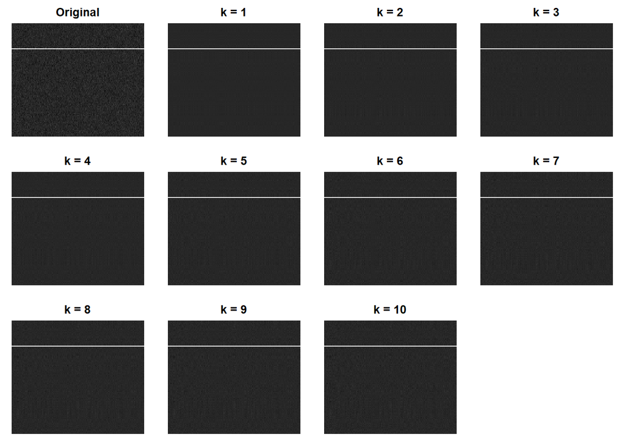

```r
plot_image <- function(mat, main = "", zlim) {
  image(mat, col = grey(seq(0, 1, length = 256)), axes = FALSE, main = main, zlim = zlim)
}


rng <- range(x)  # use original image's range as the common scale

par(mfrow = c(3, 4), mar = c(1, 1, 2, 1))
plot_image(x, main = "Original", zlim = rng)
for (k in 1:10) {
  plot_image(approximations[[k]], main = paste("k =", k), zlim = rng)
}
```

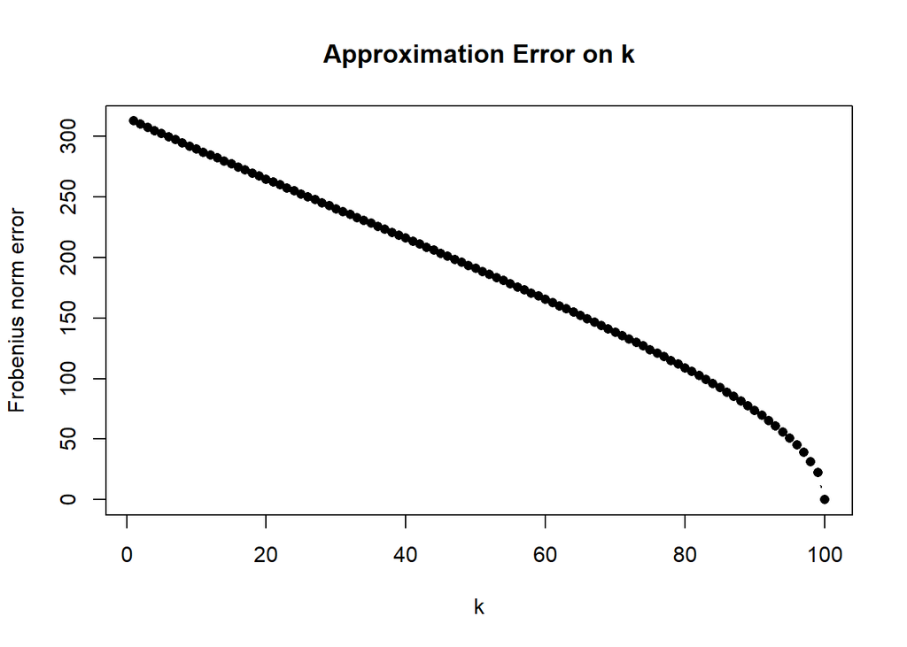

```r
p <- ncol(x)
n <- nrow(x)
max_k <- min(n, p)

errors <- numeric(max_k)
for (k in 1:max_k) {
  errors[k] <- rank_k_pca(x, k)$error
}

plot(1:max_k, errors, type = "b", pch = 16,
     xlab = "k", ylab = "Frobenius norm error",
     main = "Approximation Error on k")
```

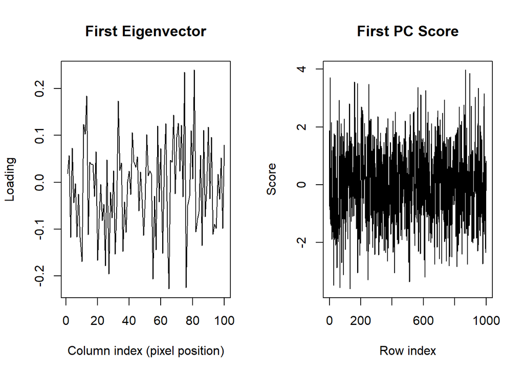

```r
pca <- prcomp(x, center = TRUE)

first_eigenvector <- pca$rotation[, 1]   # length p (one value per column/pixel-position)
first_pc_score    <- pca$x[, 1]           # length n (one value per row)

par(mfrow = c(1, 2))

plot(first_eigenvector, type = "l",
     xlab = "Column index (pixel position)", ylab = "Loading",
     main = "First Eigenvector")

plot(first_pc_score, type = "l",
     xlab = "Row index", ylab = "Score",
     main = "First PC Score")
```

**Conclusion**

For the first eigenvector the spikes oscillate rapidly between -0.2 and 0.2. This shows what the direction of the strongest variance in this image is and how it spreads across multiple columns creating noise. For the first PC Score it also has a strong spread across 1000 rows. This proves that the pattern from the first eigenvector is distributed evenly. Based on these findings, I think a k of 60/100 will show more of the original texture with more variance as well. We can compare it below

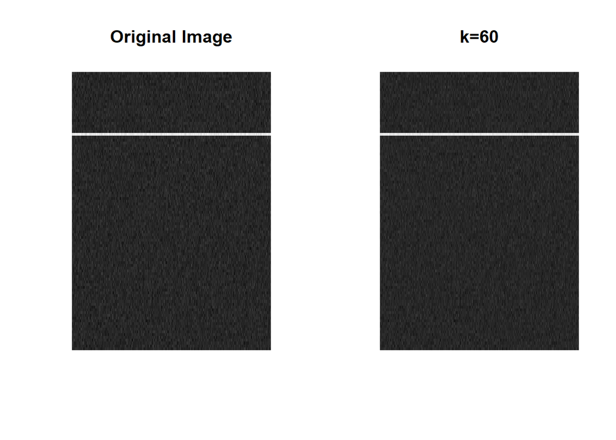

```r
par(mfrow = c(1,2))
plot_image(x, main = "Original Image", zlim = rng)
plot_image(rank_k_pca(x, 60)$approximation, main = "k=60", zlim = rng)
```

# **Image 2**

```r
# loading  new image
x <- read_csv("image2.csv")
x <- data.matrix(x)

# plot to check orientation
plot_image <- function(mat, main = "") {
  image(t(apply(mat, 2, rev)), col = grey(seq(0, 1, length = 256)),
        axes = FALSE, main = main)
}

# function
rank_k_pca <- function(x, k) {
  pca <- prcomp(x, center = TRUE)
  scores <- pca$x[, 1:k, drop = FALSE]
  loadings <- pca$rotation[, 1:k, drop = FALSE]
  x_approx <- scores %*% t(loadings)
  x_approx <- sweep(x_approx, 2, pca$center, "+")
  error <- sqrt(sum((x - x_approx)^2))
  return(list(approximation = x_approx, error = error))
}

# plot for approximations
approximations <- vector("list", 10)
for (k in 1:10) {
  approximations[[k]] <- rank_k_pca(x, k)$approximation
}
```

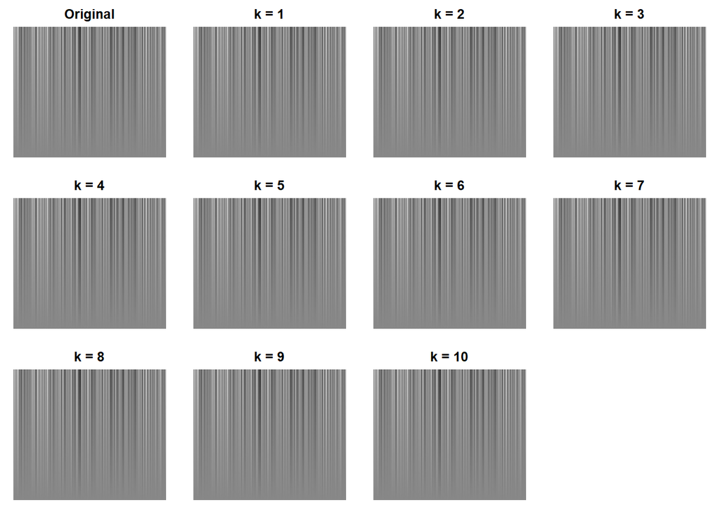

```r
plot_image <- function(mat, main = "", zlim) {
  image(mat, col = grey(seq(0, 1, length = 256)), axes = FALSE, main = main, zlim = zlim)
}


rng <- range(x)  # use original image's range as the common scale

par(mfrow = c(3, 4), mar = c(1, 1, 2, 1))
plot_image(x, main = "Original", zlim = rng)
for (k in 1:10) {
  plot_image(approximations[[k]], main = paste("k =", k), zlim = rng)
}
```

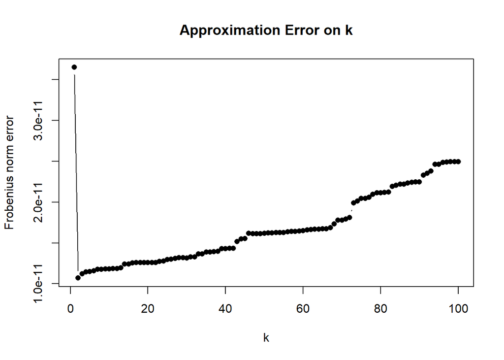

```r
p <- ncol(x)
n <- nrow(x)
max_k <- min(n, p)

errors <- numeric(max_k)
for (k in 1:max_k) {
  errors[k] <- rank_k_pca(x, k)$error
}

plot(1:max_k, errors, type = "b", pch = 16,
     xlab = "k", ylab = "Frobenius norm error",
     main = "Approximation Error on k")
```

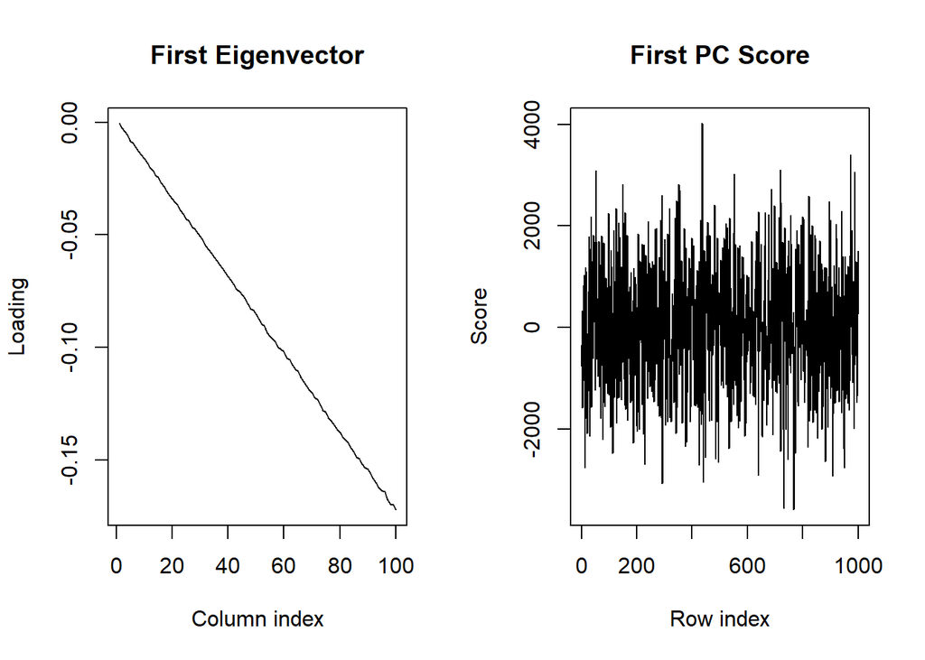

```r
pca <- prcomp(x, center = TRUE)

first_eigenvector <- pca$rotation[, 1]   # length p (one value per column/pixel-position)
first_pc_score    <- pca$x[, 1]           # length n (one value per row)

par(mfrow = c(1, 2))

plot(first_eigenvector, type = "l",
     xlab = "Column index", ylab = "Loading",
     main = "First Eigenvector")

plot(first_pc_score, type = "l",
     xlab = "Row index", ylab = "Score",
     main = "First PC Score")
```

**Conclusion**

For the first eigenvector the slopes downward between 0 and 100. This shows that as column index increases the loading decreases. For the first PC Score it has a strong spread across 1000 rows. This proves that the pattern from the first eigenvector is distributed evenly. Based on these findings, I think a k of 80/100 will show more of the original texture with more variance as well. We can compare it below

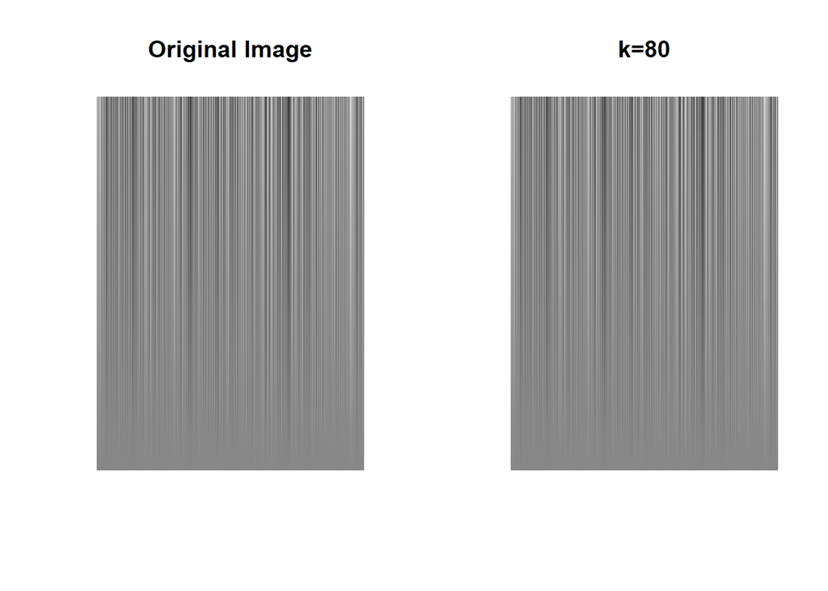

```r
par(mfrow = c(1,2))
plot_image(x, main = "Original Image", zlim = rng)
plot_image(rank_k_pca(x, 80)$approximation, main = "k=80", zlim = rng)
```

**Image 3**

```r
# loading  data
x <- read_csv("image3.csv")
x <- data.matrix(x)

# plot to check orientation
plot_image <- function(mat, main = "") {
  image(t(apply(mat, 2, rev)), col = grey(seq(0, 1, length = 256)),
        axes = FALSE, main = main)
}

# function
rank_k_pca <- function(x, k) {
  pca <- prcomp(x, center = TRUE)
  scores <- pca$x[, 1:k, drop = FALSE]
  loadings <- pca$rotation[, 1:k, drop = FALSE]
  x_approx <- scores %*% t(loadings)
  x_approx <- sweep(x_approx, 2, pca$center, "+")
  error <- sqrt(sum((x - x_approx)^2))
  return(list(approximation = x_approx, error = error))
}

# plot for approximations
approximations <- vector("list", 10)
for (k in 1:10) {
  approximations[[k]] <- rank_k_pca(x, k)$approximation
}
```

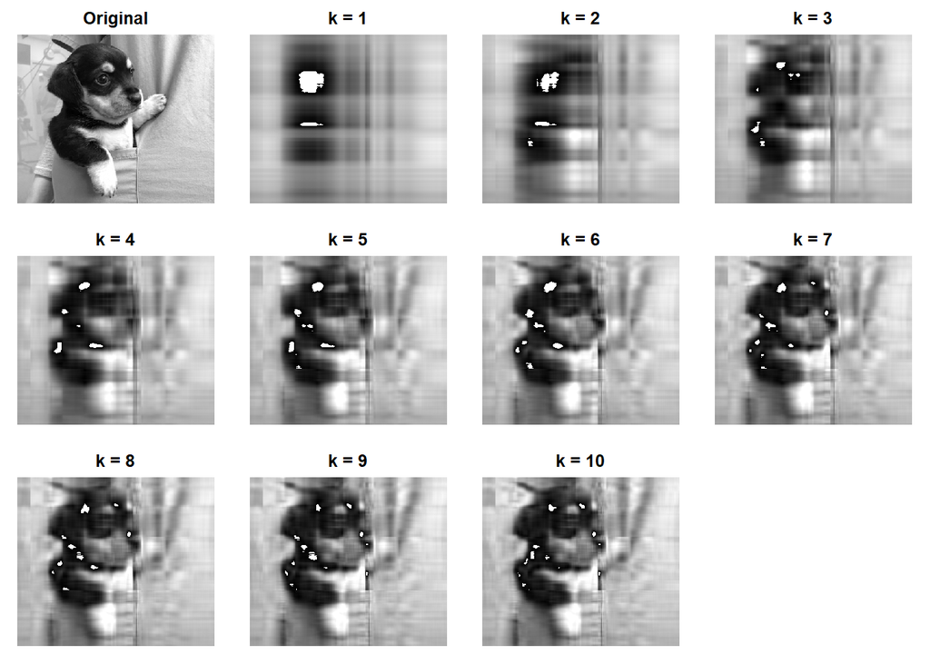

```r
plot_image <- function(mat, main = "", zlim) {
  image(mat, col = grey(seq(0, 1, length = 256)), axes = FALSE, main = main, zlim = zlim)
}


rng <- range(x)  # use original image's range as the common scale

par(mfrow = c(3, 4), mar = c(1, 1, 2, 1))
plot_image(x, main = "Original", zlim = rng)
for (k in 1:10) {
  plot_image(approximations[[k]], main = paste("k =", k), zlim = rng)
}
```

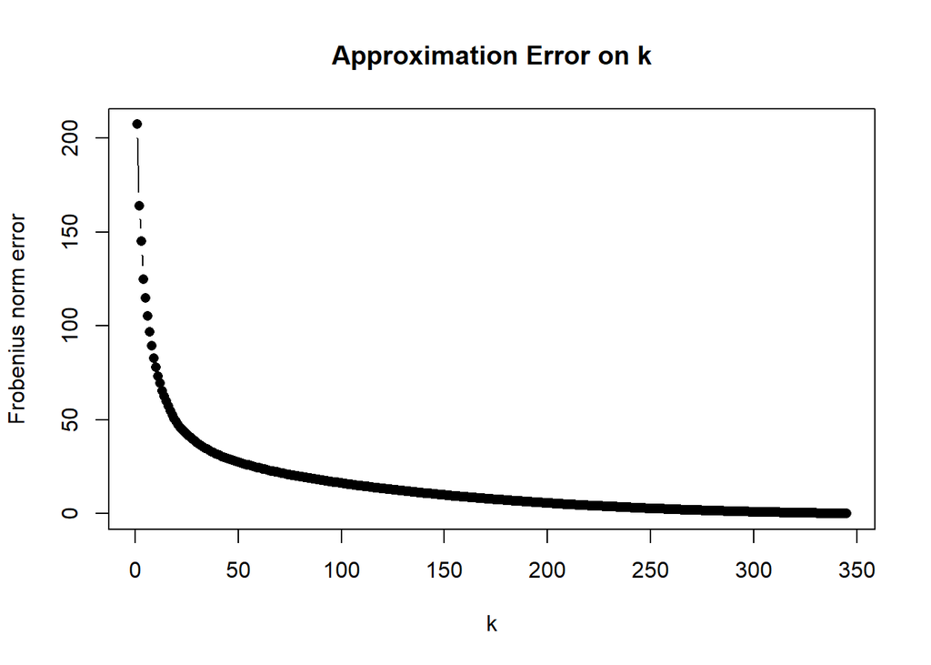

```r
p <- ncol(x)
n <- nrow(x)
max_k <- min(n, p)

errors <- numeric(max_k)
for (k in 1:max_k) {
  errors[k] <- rank_k_pca(x, k)$error
}

plot(1:max_k, errors, type = "b", pch = 16,
     xlab = "k", ylab = "Frobenius norm error",
     main = "Approximation Error on k")
```

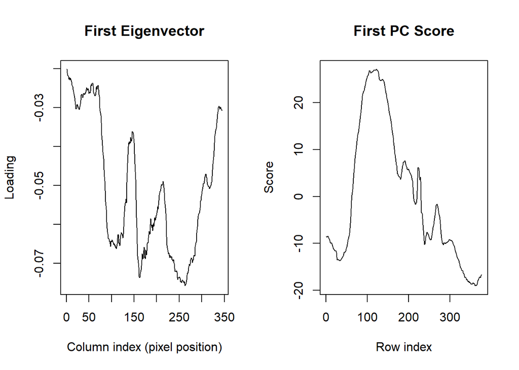

```r
pca <- prcomp(x, center = TRUE)

first_eigenvector <- pca$rotation[, 1]   # length p (one value per column/pixel-position)
first_pc_score    <- pca$x[, 1]           # length n (one value per row)

par(mfrow = c(1, 2))

plot(first_eigenvector, type = "l",
     xlab = "Column index (pixel position)", ylab = "Loading",
     main = "First Eigenvector")

plot(first_pc_score, type = "l",
     xlab = "Row index", ylab = "Score",
     main = "First PC Score")
```

**Conclusion**

For the first eigenvector the observations fluctuate between 0 and 350. This shows there is no linear direction of how loading and column index are related to each other. For the first PC Score it has a rapid increase at 100 rows and then slowly falls by 300 rows. I think a k of 80/100 will show more of the original texture with more variance as well. We can compare it below

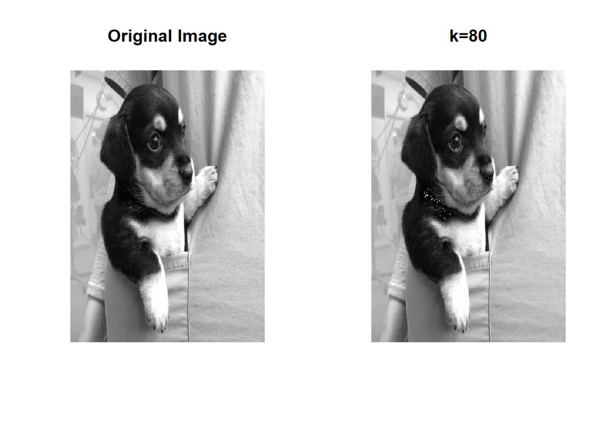

```r
par(mfrow = c(1,2))
plot_image(x, main = "Original Image", zlim = rng)
plot_image(rank_k_pca(x, 80)$approximation, main = "k=80", zlim = rng)
```

**Image 4**

```r
# loading  data
x <- read_csv("image4.csv")
x <- data.matrix(x)

# plot to check orientation
plot_image <- function(mat, main = "") {
  image(t(apply(mat, 2, rev)), col = grey(seq(0, 1, length = 256)),
        axes = FALSE, main = main)
}

# function
rank_k_pca <- function(x, k) {
  pca <- prcomp(x, center = TRUE)
  scores <- pca$x[, 1:k, drop = FALSE]
  loadings <- pca$rotation[, 1:k, drop = FALSE]
  x_approx <- scores %*% t(loadings)
  x_approx <- sweep(x_approx, 2, pca$center, "+")
  error <- sqrt(sum((x - x_approx)^2))
  return(list(approximation = x_approx, error = error))
}

# plot for approximations
approximations <- vector("list", 10)
for (k in 1:10) {
  approximations[[k]] <- rank_k_pca(x, k)$approximation
}
```

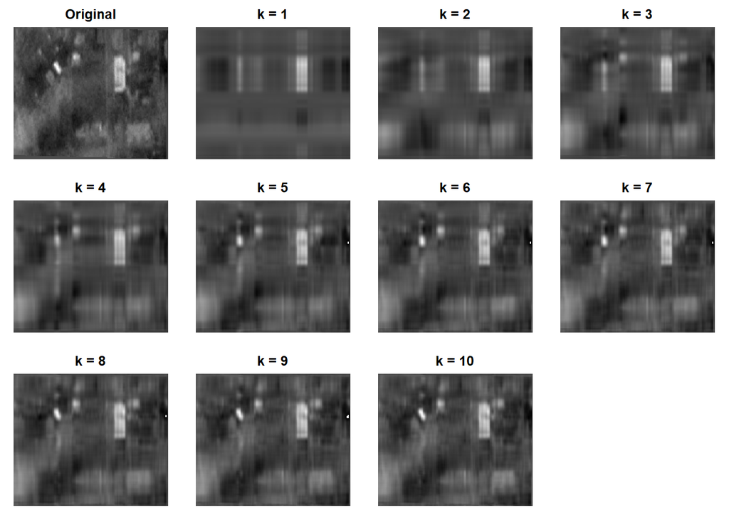

```r
plot_image <- function(mat, main = "", zlim) {
  image(mat, col = grey(seq(0, 1, length = 256)), axes = FALSE, main = main, zlim = zlim)
}


rng <- range(x)  # use original image's range as the common scale

par(mfrow = c(3, 4), mar = c(1, 1, 2, 1))
plot_image(x, main = "Original", zlim = rng)
for (k in 1:10) {
  plot_image(approximations[[k]], main = paste("k =", k), zlim = rng)
}
```

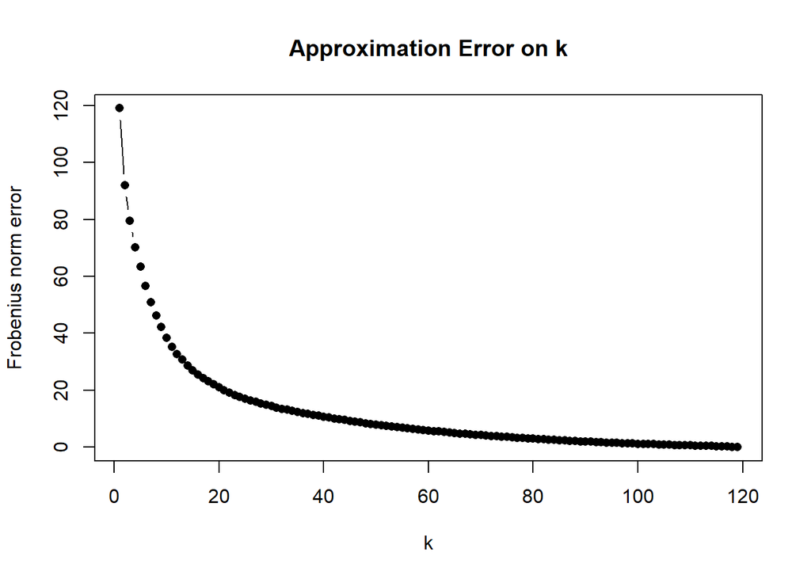

```r
p <- ncol(x)
n <- nrow(x)
max_k <- min(n, p)

errors <- numeric(max_k)
for (k in 1:max_k) {
  errors[k] <- rank_k_pca(x, k)$error
}

plot(1:max_k, errors, type = "b", pch = 16,
     xlab = "k", ylab = "Frobenius norm error",
     main = "Approximation Error on k")
```

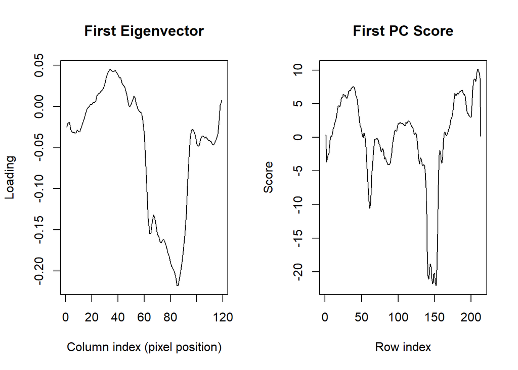

```r
pca <- prcomp(x, center = TRUE)

first_eigenvector <- pca$rotation[, 1]   # length p (one value per column/pixel-position)
first_pc_score    <- pca$x[, 1]           # length n (one value per row)

par(mfrow = c(1, 2))

plot(first_eigenvector, type = "l",
     xlab = "Column index (pixel position)", ylab = "Loading",
     main = "First Eigenvector")

plot(first_pc_score, type = "l",
     xlab = "Row index", ylab = "Score",
     main = "First PC Score")
```

**Conclusion** Both the eigenvector and first PC score have similar distributions. They both evenly spread across their ranges and show a dip on 80 (for column index eigenvector) and 150 (for row index in pc score). A high k value like 80 also creates a similar image with less variance

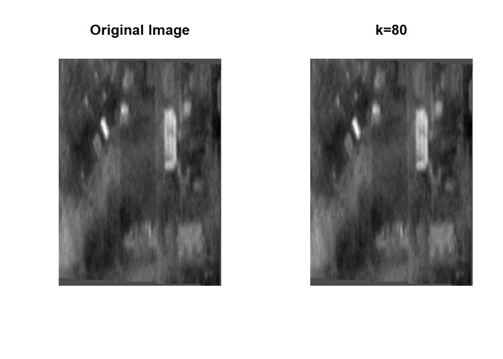

```r
par(mfrow = c(1,2))
plot_image(x, main = "Original Image", zlim = rng)
plot_image(rank_k_pca(x, 80)$approximation, main = "k=80", zlim = rng)
```

[output not shown]